# Data Club - Application d’un analyse de type Machine Learning en épidémiologie

Mathilde CHEN, Inserm, UMR 1153 CRESS, EpiAgeing

2023-01-17

Ce document décrit la procédure pour utiliser le package **plsRcox** (Bertrand et al., 2014, https://fbertran.github.io/plsRcox/) pour la régression de sparse Partial Least Square pour l’analyse de survie (sPLSCox). Cette méthode est une alternative aux analyses de survie classique en cas d’un nombre important de variables explicatives/prédicteurs très corrélés.

## Exploration rapide des données

```r
# Données
# Exemple de jeu de données
# Téléchargeable via : https://www.kaggle.com/datasets/mitishaagarwal/patient
data_init <- read.csv(file = "E:/PC_FIXE/Conferences/2023_01_17_Club Data Stats/Code/dataset.patient.survival.csv") %>%
  select(-X) %>%
  drop_na() %>% # retirer toutes les données manquantes
  mutate(ethnicity_2 = if_else(ethnicity == "Caucasian", 0, 1)) %>% # Ethnicité majoritaire = Caucasienne (codé comme ref)
  mutate(sex = if_else(gender == "M", 0, 1))                        # Catégorie majoritaire = Homme (codé comme ref)

dim(data_init) # 57598 patients

# Sélection d'un 1/10 du jeu de données
set.seed(1)
data_id <- createFolds(data_init$hospital_death, k=20)

data <- data_init[data_id$Fold01,]
dim(data) # 2880

# Générer les durées de survie
set.seed(123)
data$hospital_time <- rnorm(nrow(data), mean = 8.13, sd = 2)
# Vérifier qu'il n'y a pas de temps < 0 année
hist(data$hospital_time)

# Multimorbidity index
data <- data %>%
  group_by(patient_id) %>%
  mutate(multimorbidity = sum(aids, cirrhosis, diabetes_mellitus, hepatic_failure, immunosuppression,
                              leukemia, lymphoma, solid_tumor_with_metastasis)) %>% ungroup()

table(data$multimorbidity, exclude=NULL)
#    0    1    2    3
# 2078  720   67   15

# Select variables
data <- data %>%
  select(patient_id, hospital_time, hospital_death,
         age, sex, ethnicity_2, bmi, multimorbidity,
         d1_diasbp_max, d1_diasbp_min,
         d1_heartrate_max, d1_heartrate_min,
         d1_mbp_max, d1_mbp_min,
         d1_resprate_max, d1_resprate_min,
         d1_spo2_max, d1_spo2_min,
         d1_sysbp_max, d1_sysbp_min,
         d1_temp_max, d1_temp_min,
         h1_diasbp_max, h1_diasbp_min,
         h1_heartrate_max, h1_heartrate_min,
         h1_mbp_max, h1_mbp_min,
         h1_resprate_max, h1_resprate_min,
         h1_spo2_max, h1_spo2_min,
         h1_sysbp_max, h1_sysbp_min,
         d1_glucose_max, d1_glucose_min,
         d1_potassium_max, d1_potassium_min)

write.csv(data, "E:/PC_FIXE/Conferences/2023_01_17_Club Data Stats/Code/dataset.patient.survival_2.csv")
```

|  | 0 (N=2625) | 1 (N=255) | Total (N=2880) | p value |
| --- | --- | --- | --- | --- |
| Durée de suivi (années) | 8.136 (1.978) | 8.292 (2.014) | 8.150 (1.981) | 0.233 |
| Age (années) | 62.290 (16.871) | 69.706 (14.650) | 62.946 (16.816) | < 0.001 |
| Femmes | 0.472 (0.499) | 0.451 (0.499) | 0.470 (0.499) | 0.521 |
| Ethnicité non caucasienne | 0.219 (0.413) | 0.227 (0.420) | 0.219 (0.414) | 0.746 |
| Indice de masse corporelle (kg/m²) | 29.439 (8.253) | 28.615 (8.749) | 29.366 (8.300) | 0.130 |
| Nombre de maladies chroniques | 0.309 (0.535) | 0.345 (0.594) | 0.312 (0.541) | 0.308 |
| d1_diasbp_max | 89.598 (19.275) | 90.831 (22.181) | 89.707 (19.549) | 0.336 |
| d1_diasbp_min | 50.723 (13.333) | 42.459 (12.567) | 49.991 (13.471) | < 0.001 |
| d1_heartrate_max | 102.428 (21.323) | 115.655 (25.421) | 103.599 (22.035) | < 0.001 |
| d1_heartrate_min | 70.687 (16.012) | 69.467 (23.500) | 70.579 (16.809) | 0.268 |
| d1_mbp_max | 105.952 (20.657) | 107.345 (24.941) | 106.076 (21.070) | 0.314 |
| d1_mbp_min | 65.770 (15.504) | 54.584 (15.112) | 64.780 (15.791) | < 0.001 |
| d1_resprate_max | 28.808 (10.370) | 33.302 (11.227) | 29.206 (10.525) | < 0.001 |
| d1_resprate_min | 13.010 (4.973) | 13.855 (5.917) | 13.085 (5.068) | 0.011 |
| d1_spo2_max | 99.190 (1.396) | 99.137 (2.555) | 99.186 (1.533) | 0.597 |
| d1_spo2_min | 91.043 (8.401) | 86.161 (13.726) | 90.611 (9.103) | < 0.001 |
| d1_sysbp_max | 149.893 (25.876) | 149.596 (29.484) | 149.867 (26.210) | 0.863 |
| d1_sysbp_min | 98.197 (19.877) | 81.588 (20.677) | 96.726 (20.496) | < 0.001 |
| d1_temp_max | 37.298 (0.658) | 37.237 (1.005) | 37.293 (0.696) | 0.184 |
| d1_temp_min | 36.321 (0.618) | 35.768 (1.263) | 36.272 (0.717) | < 0.001 |
| h1_diasbp_max | 76.585 (18.341) | 74.976 (20.764) | 76.443 (18.570) | 0.187 |
| h1_diasbp_min | 64.422 (16.186) | 56.604 (17.399) | 63.730 (16.444) | < 0.001 |
| h1_heartrate_max | 92.376 (21.681) | 99.918 (23.934) | 93.044 (21.990) | < 0.001 |
| h1_heartrate_min | 84.108 (20.405) | 88.235 (22.203) | 84.474 (20.600) | 0.002 |
| h1_mbp_max | 92.453 (20.510) | 90.125 (23.690) | 92.247 (20.817) | 0.088 |
| h1_mbp_min | 80.968 (19.097) | 71.082 (20.183) | 80.093 (19.396) | < 0.001 |
| h1_resprate_max | 22.737 (7.277) | 26.141 (8.492) | 23.039 (7.454) | < 0.001 |
| h1_resprate_min | 17.397 (5.980) | 19.345 (7.073) | 17.570 (6.108) | < 0.001 |
| h1_spo2_max | 98.016 (2.426) | 97.722 (3.854) | 97.990 (2.585) | 0.082 |
| h1_spo2_min | 95.297 (6.038) | 92.761 (8.490) | 95.073 (6.333) | < 0.001 |
| h1_sysbp_max | 134.448 (27.798) | 129.647 (30.211) | 134.023 (28.048) | 0.009 |
| h1_sysbp_min | 118.182 (25.953) | 103.918 (28.301) | 116.919 (26.476) | < 0.001 |
| d1_glucose_max | 171.695 (84.621) | 203.769 (108.860) | 174.535 (87.493) | < 0.001 |
| d1_glucose_min | 114.732 (38.032) | 116.788 (47.636) | 114.914 (38.972) | 0.421 |
| d1_potassium_max | 4.218 (0.643) | 4.507 (0.861) | 4.244 (0.670) | < 0.001 |
| d1_potassium_min | 3.936 (0.576) | 3.996 (0.771) | 3.942 (0.596) | 0.124 |

Parmi les variables disponibles, on voit que la valeur maximale et minimale de nombreux biomarqueurs sont disponibles (variables dont le nom commence par “d1”). Certains sont particulièrement corrélés entre eux.

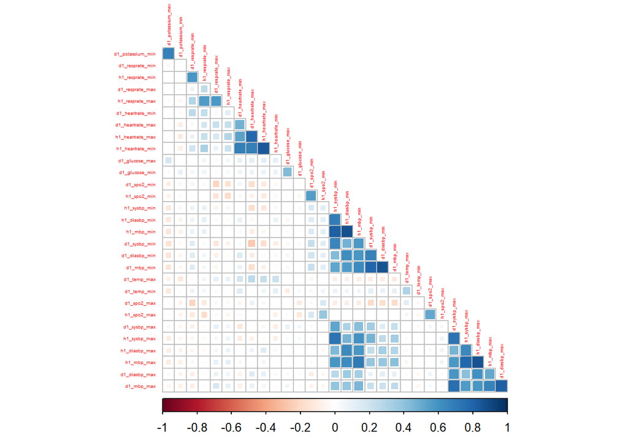

## Procédure de validation croisée

Avant d’ajuster le modèle sPLSCox, il faut choisir la valeur optimale de deux hyper-paramètres: (1) **ncomp**: le nombre de composantes latentes calculées par le modèle et (2) **eta** : le seuil de sparsité, c’est-à-dire la pression de sélection des variables. Plus le seuil de sélection est élevé, plus les variables sélectionnées par l’algorithme sont associées à la sruvie des patients.

La sélection des valeur de ces deux paramètres est cruciale car elles vont déterminer le nombre de variables sélectionnées ainsi que le nombre de composantes latentes issues de la sPLSCox. Afin de prévenir le risque d’overfitting, il est nécessaire de définir ces valeurs par validation croisée.

### Déclaration des variables et partition des données

```r
# > Prédicteurs (Biomarqueurs disponibles dans le jeu de données)
Xplan <- data %>%
  select(d1_diasbp_max, d1_diasbp_min,
         d1_heartrate_max, d1_heartrate_min,
         d1_mbp_max, d1_mbp_min,
         d1_resprate_max, d1_resprate_min,
         d1_spo2_max, d1_spo2_min,
         d1_sysbp_max, d1_sysbp_min,
         d1_temp_max, d1_temp_min,
         h1_diasbp_max, h1_diasbp_min,
         h1_heartrate_max, h1_heartrate_min,
         h1_mbp_max, h1_mbp_min,
         h1_resprate_max, h1_resprate_min,
         h1_spo2_max, h1_spo2_min,
         h1_sysbp_max, h1_sysbp_min,
         d1_glucose_max, d1_glucose_min,
         d1_potassium_max, d1_potassium_min) # 30 prédicteurs

# > Survie
Cas <- data$hospital_death # 255 décès
T <- data$hospital_time    # Suivi moyen (écart-type) : 8.2 (2) années

# > Partition des données en 5 groupes
set.seed(456)
folds <- createFolds(y = Cas, k = 5)
```

### Validation croisée avec plsRcox

Le package plsRCox contient la fonction **cv.coxsplsDR()**, dont le but est de “cross-valider” les modèles ajustés par la function **coxsplsDR()**. La fonction va évaluer la performance de l’algorithme pour une valeur de eta donnée (par défaut eta=0.5) et pour un nombre de composantes latentes variant de 0 à l’argument **nt** (par défaut 10). Ici, on définit nt = 5.

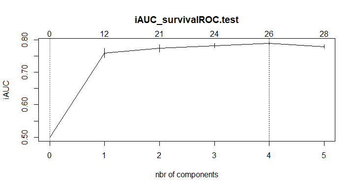

```r
# > Afin de réduire le temps de calcul, on peut paralléliser l'opération
# >>> start cluster
N_core_in_computer <- detectCores()-1
Create_socket <- makePSOCKcluster(N_core_in_computer)
Register_your_parameters <- registerDoParallel(Create_socket)


# Utilisation de cv.coxsplsDR
cv_test <- cv.coxsplsDR(list(x = Xplan, time = T, status = Cas),
                    nt = 5,             # varie de 0 à ncomp (ici 5)
                    eta = 0.5,          # seuil de sparsité
                    givefold = folds,   # il est possible de fournir la partition des données; si non, la fonction partitionne elle-même les données
                    scaleX = TRUE,      # standardiser X (TRUE: oui, FALSE : non)
                    scaleY = FALSE,     # standardiser Y (TRUE: oui, FALSE : non)
                    plot.it = TRUE)     # représentation graphique des résultats


# >>> stop cluster//
stopCluster(Create_socket)

save(cv_test, file = "E:/PC_FIXE/Conferences/2023_01_17_Club Data Stats/R.objects/cv_test.rda")
```

Le graphique représente la performance de l’algorithme pour chaque valeur de ncomp (pour une même valeur de eta, i.e. eta = 0.5). Le critère d’évaluation utilisé ici est iAUC, mais la fonction peut calculer en tout 13 critères d’évaluations différents, dont la liste est dans l’aide R de la fonction (taper **?cv.coxsplsDR** dans la console). Pour calculer tous les critères, il faut ajouter **allCVcrit=TRUE** dans les arguments de la fonction. Ce graphique montre que Pour une valeur de eta = 0.5, la valeur optimale de composantes latentes (ncomp) obtenue par la fonction est ncomp = 4 et le nombre de variables retenues dans le modèle est de 26. Le problème c’est que cette fonction ne va tester qu’une seule valeur de eta à la fois. Dans notre cas, on souhaite choisir la valeur de ncomp et la valeur de eta.

La sortie de cette fonction contient différentes informations :

```r
# > la valeur de ncomp
cv_test$nt
```

```
## [1] 5
```

```r
# > les valeurs moyenne d'iAUC par chaque valeur de ncomp
cv_test$cv.error10
```

```
## [1] 0.50 0.76 0.77 0.78 0.79 0.78
```

```r
# > les écarts type associés
cv_test$cv.se10
```

```
## [1] 0.0000 0.0141 0.0108 0.0066 0.0027 0.0052
```

```r
# > la valeur optimale de ncomp
cv_test$lambda.min10
```

```
## [1] 4
```

```r
# > le nombre de variables sélectionnées
cv_test$nzb
```

```
## [1]  0 12 21 24 26 28
```

### Validation croisée avec une fonction “maison”

Afin de pouvoir tester toutes les combinaisons des valeurs de eta et de ncomp, je propose ici une fonction développée à partir de la fonction **cv.coxsplsDR()** et qui va automatiser le processus pour une grille de plusieurs valeurs de eta.

```r
# Function for cross-validation:
# Arguments should be:
# - x = Xplan, predictors
# - time = T, survival time
# - status = Cas, vital status at the end of the follow up
# - eta = une grille de valeurs à tester pour le paramètre eta
# - ncomp = la valeur maximale de composantes à tester
# - scale.x = TRUE/FALSE, indique si la fonction doit elle même standardiser les prédicteurs

cv_eta_ncomp <- function(x, time, status, eta, ncomp, folds, scale.x){

  # >>> 5-folds cross-validation
  cv_e = cv.coxsplsDR(list(x = x, time = time, status = status), # arguments décrivant les prédicteurs, le temps de suivi et le statut vital
                      nt = ncomp,                                # varies from 0 to ncomp
                      eta = eta,                                 # varies according to eta grid provided
                      givefold = folds,                          # provide folds to have consistent partition during the cross-validation
                      scaleX = scale.x,                          # TRUE = scale Xplan ; FALSE = do not scale Xplan (if already scaled)
                      scaleY = FALSE,                            # do not scale Y
                      plot.it = FALSE)                           # do not plot the results of the cv.coxsplsDR() function

  # >>> format results into a table
  perf_e <- data.frame(eta        = eta,             # value of eta
                       n_nt       = 0:cv_e$nt,       # value of ncomp
                       cv.error10 = cv_e$cv.error10, # predictive mean value (iAUC criterion) of the eta*ncomp combinaison over the 5 folds
                       cv.se10    = cv_e$cv.se10)    # corresponding standard error

  # >>> return the CV object and the table with results for each combination of ncomp and eta
  return(list("cv_object" = cv_e,
              "perf_e" = perf_e))


}
```

```r
# > Grille de la valeur eta
grille_eta <- seq(0.05, 0.95, by=0.05)
grille_eta

# > Afin de réduire le temps de calcul, on peut paralléliser l'opération
# >>> start cluster
N_core_in_computer <- detectCores()-1
Create_socket <- makePSOCKcluster(N_core_in_computer)
Register_your_parameters <- registerDoParallel(Create_socket)


# > Application de la fonction "maison" sur la grille de eta prédéfinie
cv_auto <- lapply(grille_eta,                         # pour chaque valeur de eta
                  cv_eta_ncomp,                       # appliquer la fonction cv_eta_ncomp définie précédemment
                  ncomp = 5,                          # en faisant varier ncomp de 0 à 5
                  folds = folds,                      # afin de garder la même partition des données durant toute la procédure
                  x = Xplan, time = T, status = Cas)  # mêmes arguments que précédemment pour les prédicteurs, le temps de suivi et le statut vital


# >>> stop cluster//
stopCluster(Create_socket)

save(cv_auto, file = "E:/PC_FIXE/Conferences/2023_01_17_Club Data Stats/R.objects/cv_auto.rda")
```

### Extraction des résultats de la validation croisée

Extraction des résultats, c’est-à-dire pour chaque paire de eta*ncomp : (1) un tableau avec la performance moyenne de l’algorithme calculée sur les 5 parties du jeu de données (cv.error10) et (2) le nombre de prédicteurs sélectionnés

```r
# > Extraction des résultats (sous forme de liste)
tab_perf_cv <- map_dfr(cv_auto, ~ { data.frame(.x$perf_e,
                                               n_select = .x$cv_object$nzb) })
```

On affiche ici la meilleure combinaison de eta * ncomp en se basant sur le critère iAUC (ce critère a été choisi par les auteurs du package qui l’ont classé comme le plus fiable pour ce type de modèle ; il existe en tout 13 critères calculés par la fonction cv.coxsplsDR).

```r
options(digits = 10)
tab_perf_cv %>%
  arrange(desc(cv.error10)) %>%
  head() %>%
  kbl() %>%
  kable_styling()
```

| eta | n_nt | cv.error10 | cv.se10 | n_select |
| --- | --- | --- | --- | --- |
| 0.75 | 4 | 0.7934189500 | 0.0014268219 | 19 |
| 0.55 | 4 | 0.7933737361 | 0.0029634647 | 27 |
| 0.75 | 5 | 0.7922871188 | 0.0012770790 | 21 |
| 0.60 | 4 | 0.7915197118 | 0.0027676883 | 26 |
| 0.65 | 5 | 0.7915098755 | 0.0020339722 | 25 |
| 0.25 | 4 | 0.7907270891 | 0.0022623199 | 30 |

On peut aussi représentation graphiquement les résultats de la validation croisée :

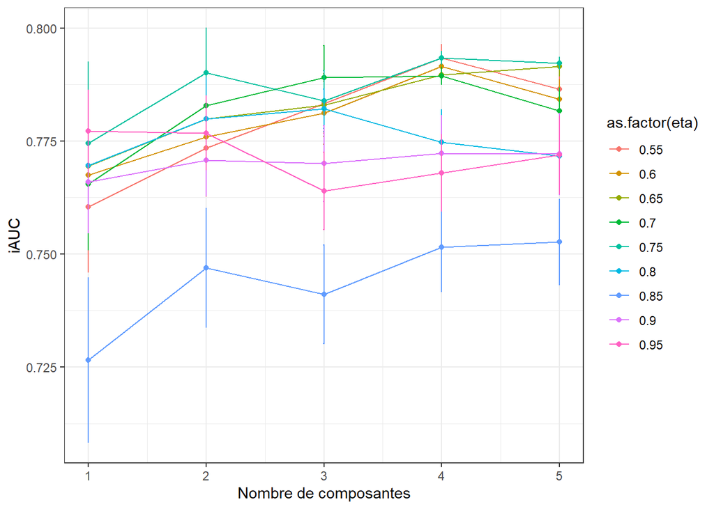

```r
# 1. Performance de l'algorithme
tab_perf_cv %>%
  filter(n_nt > 0, eta > 0.5) %>%
  ggplot(., aes(x = n_nt, y = cv.error10, color = as.factor(eta))) +
  geom_line() +
  geom_point() +
  geom_errorbar(aes(ymin = cv.error10-cv.se10, ymax = cv.error10+cv.se10), width=0.01) +
  theme_bw() +
  labs(x = "Nombre de composantes", y = "iAUC")
```

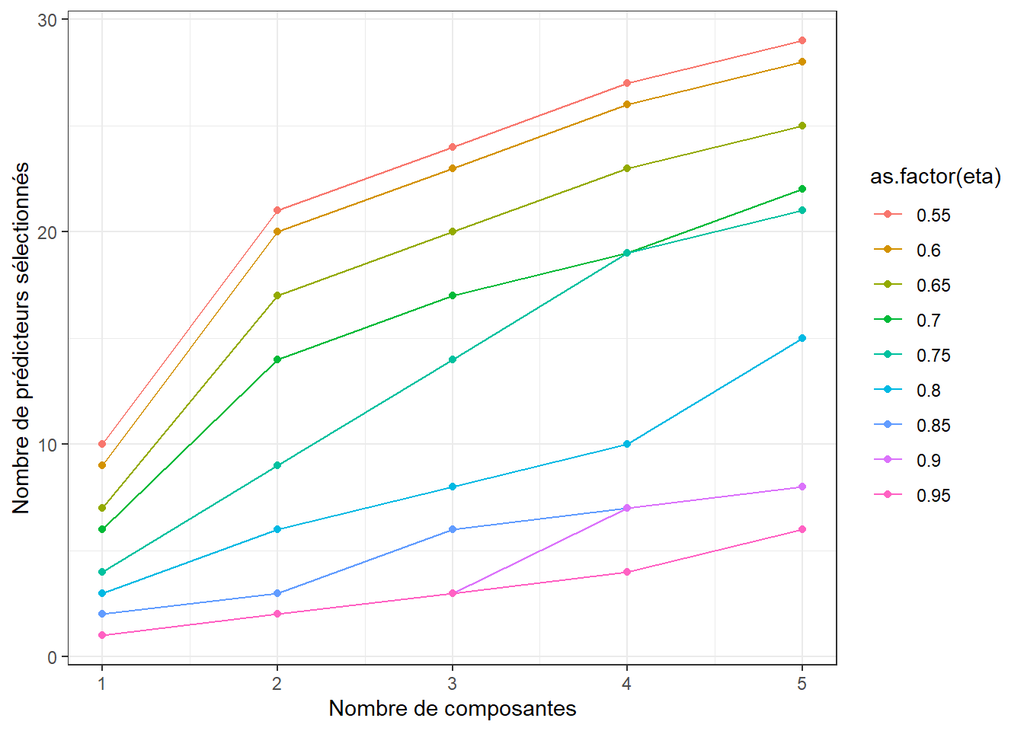

```r
# 2. Nombre de variables sélectionnées
tab_perf_cv %>%
  filter(n_nt > 0, eta > 0.5) %>%
  ggplot(., aes(x = n_nt, y = n_select, color = as.factor(eta))) +
  geom_line() +
  geom_point() +
  theme_bw() +
  labs(x = "Nombre de composantes", y = "Nombre de prédicteurs sélectionnés")
```

Plus le niveau de sparsité est faible, plus on inclu de variables. Plus on augmente le nombre de composantes, plus on augmente le nombre de variables.

Si nécessaire, on peut refaire une nouvelle procédure de validation croisée sur une grille restreinte et plus fine de eta.

## Calcul des composantes latentes en utilisant les hyper-paramètres sélectionnés par la procédure de validation croisée

```r
# > Ajustement du modèle sPLS
sPLS_fit  = coxsplsDR(Xplan, T, Cas,
                      ncomp = 4,
                      eta = 0.75,
                      allres = TRUE,
                      scaleX = TRUE,
                      scaleY = FALSE)
```

```r
# > Extraction des composantes latentes estimées par le modèle
components_sPLS <- sPLS_fit$tt_splsDR

# > Incorporation des composantes dans le jeu de données initial
new_data <- cbind(data, components_sPLS)
```

On peut déjà s’intéresser à l’association de ces composantes avec la mortalité :

|  | 0 (N=2625) | 1 (N=255) | Total (N=2880) | p value |
| --- | --- | --- | --- | --- |
| **Composante 1** | -0.156 (1.328) | 1.607 (1.662) | -0.000 (1.450) | < 0.001 |
| **Composante 2** | -0.059 (1.488) | 0.604 (1.988) | 0.000 (1.550) | < 0.001 |
| **Composante 3** | -0.023 (1.000) | 0.235 (1.644) | 0.000 (1.075) | < 0.001 |
| **Composante 4** | -0.008 (0.902) | 0.084 (1.113) | 0.000 (0.923) | 0.128 |

```r
# > Extraction des poids attribués à chaque variable lors de la
#   construction des variables latentes
loadings_sPLS <- data.frame(varname = rownames(sPLS_fit$splsDR_modplsr$loadings$X),
                            sPLS_fit$splsDR_modplsr$loadings$X, row.names = NULL)

loadings_sPLS %>%
  kbl() %>%
  kable_styling()
```

| varname | comp.1 | comp.2 | comp.3 | comp.4 |
| --- | --- | --- | --- | --- |
| d1_heartrate_max | 0.34 | 0.03 | 0.00 | 0.71 |
| d1_heartrate_min | -0.03 | -0.25 | -0.29 | 0.08 |
| d1_mbp_max | 0.04 | 0.34 | -0.37 | -0.09 |
| d1_mbp_min | -0.40 | 0.23 | 0.10 | 0.20 |
| d1_resprate_min | 0.11 | 0.14 | 0.28 | 0.38 |
| d1_spo2_max | -0.02 | -0.22 | -0.34 | 0.09 |
| d1_spo2_min | -0.29 | 0.05 | 0.28 | 0.13 |
| d1_sysbp_max | -0.02 | 0.35 | -0.35 | -0.04 |
| d1_sysbp_min | -0.46 | 0.16 | -0.10 | -0.18 |
| d1_temp_min | -0.43 | -0.43 | -0.38 | 0.36 |
| h1_mbp_max | -0.06 | 0.44 | -0.12 | 0.19 |
| h1_resprate_max | 0.26 | 0.02 | -0.28 | 0.09 |
| h1_resprate_min | 0.17 | -0.05 | -0.24 | -0.09 |
| h1_sysbp_max | -0.10 | 0.41 | -0.18 | 0.15 |
| d1_glucose_max | 0.20 | 0.03 | -0.20 | -0.10 |
| d1_potassium_max | 0.27 | 0.05 | 0.02 | -0.18 |

Représentation graphique du poids des variables :

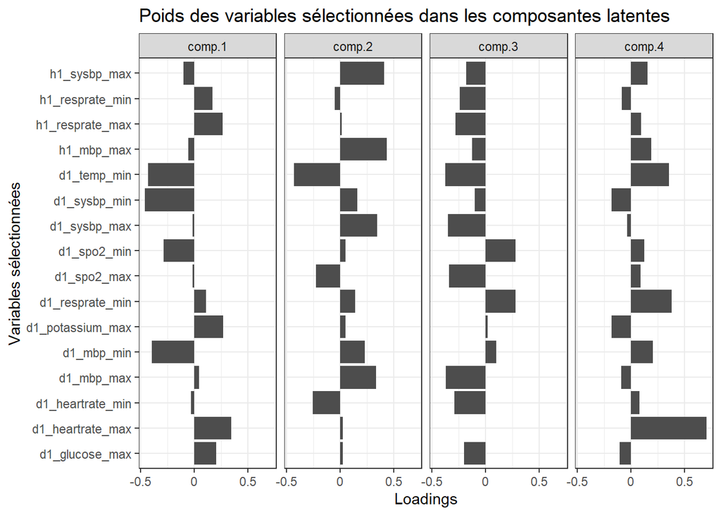

```r
loadings_sPLS %>%
  pivot_longer(cols = c("comp.1","comp.2", "comp.3", "comp.4"),
               names_to = "composante") %>%
ggplot(data = , aes(x=value, y=varname)) +
  geom_col(fill = "grey30") +
  facet_grid(.~composante) +
  labs(x = "Loadings", y = "Variables sélectionnées") +
  theme_bw() +
  ggtitle("Poids des variables sélectionnées dans les composantes latentes") +
  scale_x_continuous(breaks = c(-0.5, 0, 0.5), labels = c(-0.5, 0, 0.5))
```

## Utilisation des composantes dans une analyse de survie

Ajustement du modèle sans les composantes :

```r
M1 <- coxph(Surv(hospital_time, hospital_death) ~
                   age + bmi + ethnicity_2 + sex, # facteurs de confusion
                 data = new_data)
```

|  | HR.lab | p.value.lab |
| --- | --- | --- |
| age | 1.03 (1.02, 1.04) | <.001 |
| bmi | 0.99 (0.98, 1.01) | 0.46 |
| ethnicity_2 | 1.21 (0.90, 1.63) | 0.2 |
| sex | 0.91 (0.71, 1.17) | 0.46 |

Ajustementr du modèle avec composantes :

```r
M1_dim <- coxph(Surv(hospital_time, hospital_death) ~ dim.1 + dim.2 + dim.3 + dim.4 +   # Composantes dérivées de la régression sPLS
                   age + bmi + ethnicity_2 + sex, # facteurs de confusion
                 data = new_data)
```

|  | HR.lab | p.value.lab |
| --- | --- | --- |
| dim.1 | 1.66 (1.55, 1.78) | <.001 |
| dim.2 | 1.09 (1.01, 1.17) | 0.027 |
| dim.3 | 1.03 (0.95, 1.12) | 0.45 |
| dim.4 | 1.18 (1.05, 1.33) | 0.0049 |
| age | 1.03 (1.02, 1.04) | <.001 |
| bmi | 0.99 (0.98, 1.01) | 0.28 |
| ethnicity_2 | 1.14 (0.85, 1.54) | 0.39 |
| sex | 0.88 (0.69, 1.13) | 0.33 |

Les composantes 1, 2, et 4 sont associées à la mortalité, mais pas la 3ème.